# Data Visualization: `ggplot` part 3

## Adjusting the x and y limits

There are many options for adjusting the x and y axes. For details, look over examples in the [R Cookbook](http://www.cookbook-r.com/). To adjust limits, we can use the `xlim` and `ylim` commands. When you do this, any data outside the specified ranges are not plotted.

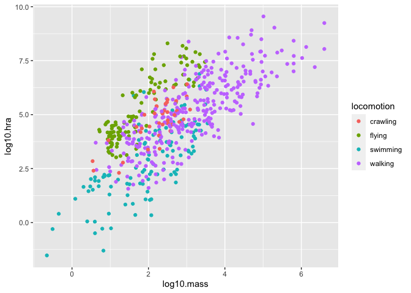

```r
homerange %>%
  ggplot(aes(x = log10.mass, y = log10.hra, color = locomotion)) +
  geom_point()
```

```r
#What if we're only interested in a certian area of the plot or point? xlim and ylim
```

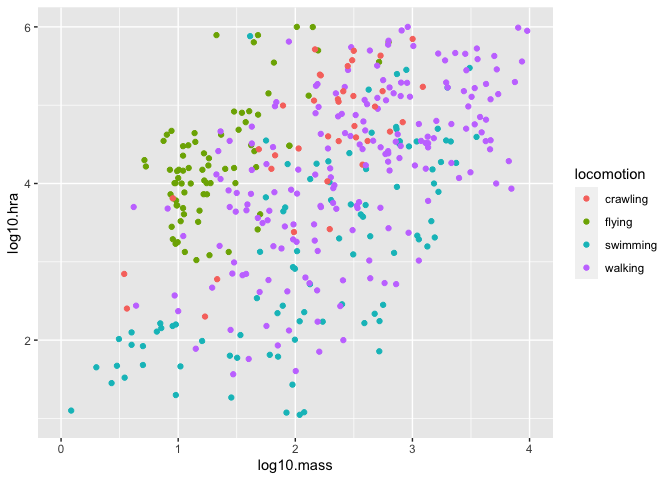

```r
homerange %>%
  ggplot(aes(x = log10.mass, y = log10.hra, color = locomotion)) +
  geom_point() +
  xlim(0, 4) +
  ylim(1, 6)
```

```r
#Warning is there because there's that many values that aren't in your lim plot
```

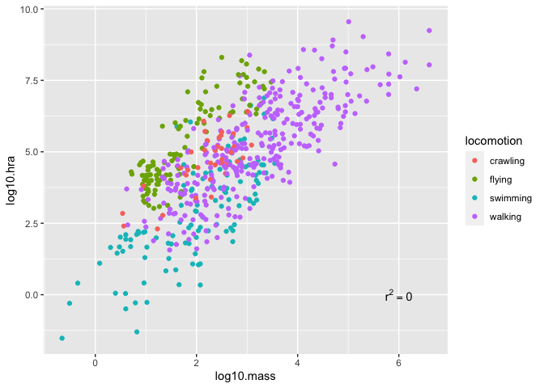

```r
homerange %>%
  ggplot(aes(x = log10.mass, y = log10.hra, color = locomotion)) +
  geom_point() +
  annotate("text", label="r^2==0", parse=T, x=6, y=0)
```

```r
#Parse converts special characters. Need to tell it where you want to put it by identifying X and Y axis
```

## Practice

1. Revisit the relationship between mass and homerange using a scatterplot, but color the points by taxonomic class using a custom color theme.

```r
glimpse(homerange)
```

```
## Rows: 569
## Columns: 24
## $ taxon                      <chr> "lake fishes", "river fishes", "river fish…
## $ common.name                <chr> "american eel", "blacktail redhorse", "cen…
## $ class                      <chr> "actinopterygii", "actinopterygii", "actin…
## $ order                      <chr> "anguilliformes", "cypriniformes", "cyprin…
## $ family                     <chr> "anguillidae", "catostomidae", "cyprinidae…
## $ genus                      <chr> "anguilla", "moxostoma", "campostoma", "cl…
## $ species                    <chr> "rostrata", "poecilura", "anomalum", "fund…
## $ primarymethod              <chr> "telemetry", "mark-recapture", "mark-recap…
## $ N                          <chr> "16", NA, "20", "26", "17", "5", "2", "2",…
## $ mean.mass.g                <dbl> 887.00, 562.00, 34.00, 4.00, 4.00, 3525.00…
## $ log10.mass                 <dbl> 2.9479236, 2.7497363, 1.5314789, 0.6020600…
## $ alternative.mass.reference <chr> NA, NA, NA, NA, NA, NA, NA, NA, NA, NA, NA…
## $ mean.hra.m2                <dbl> 282750.00, 282.10, 116.11, 125.50, 87.10, …
## $ log10.hra                  <dbl> 5.4514026, 2.4504031, 2.0648696, 2.0986437…
## $ hra.reference              <chr> "Minns, C. K. 1995. Allometry of home rang…
## $ realm                      <chr> "aquatic", "aquatic", "aquatic", "aquatic"…
## $ thermoregulation           <chr> "ectotherm", "ectotherm", "ectotherm", "ec…
## $ locomotion                 <chr> "swimming", "swimming", "swimming", "swimm…
## $ trophic.guild              <chr> "carnivore", "carnivore", "carnivore", "ca…
## $ dimension                  <chr> "3D", "2D", "2D", "2D", "2D", "2D", "2D", …
## $ preymass                   <dbl> NA, NA, NA, NA, NA, NA, 1.39, NA, NA, NA, …
## $ log10.preymass             <dbl> NA, NA, NA, NA, NA, NA, 0.1430148, NA, NA,…
## $ PPMR                       <dbl> NA, NA, NA, NA, NA, NA, 530, NA, NA, NA, N…
## $ prey.size.reference        <chr> NA, NA, NA, NA, NA, NA, "Brose U, et al. 2…
```

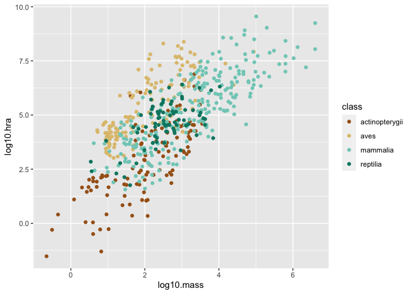

```r
homerange %>%
  ggplot(aes(x = log10.mass, y = log10.hra, color = class))+
  geom_point()+
  scale_color_brewer(palette = "BrBG")
```

2. Build bar plots that show the representation by taxonomic class with carnivores and herbivores. Try using a color theme that matches your scatterplot to keep everything consistent.

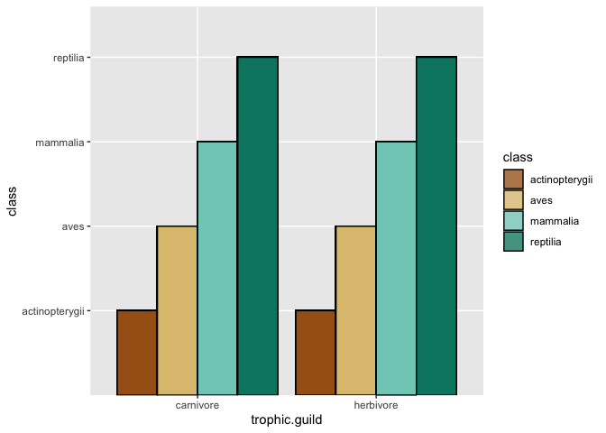

```r
homerange %>%
  ggplot(aes(x = trophic.guild, y = class, fill = class))+
  geom_col(position="dodge", alpha = 0.75, color = "black")+
  scale_fill_brewer(palette = "BrBG")
```

## Faceting: `facet_wrap()`

```r
p2 <- homerange %>%
  ggplot(aes(x = log10.mass)) +
  geom_density()
#Basically building a series of plots stacked all at once
#So we're doing density distribution for now
#How would you make desnity plots for every animal? You'd have to filter for all of them... BUT thanks to facet, not really!
```

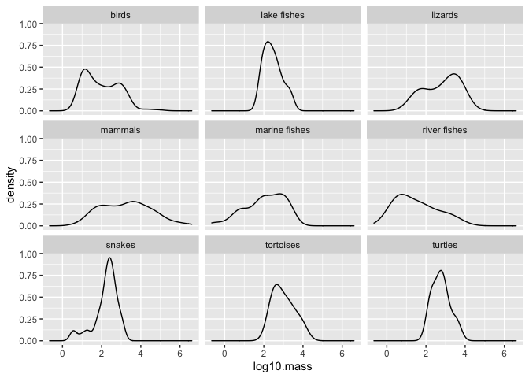

```r
p2+ facet_wrap(~taxon)
```

```r
#~ =  "by", so "wrap by taxon"
#You get density plots for all the different data at once
```

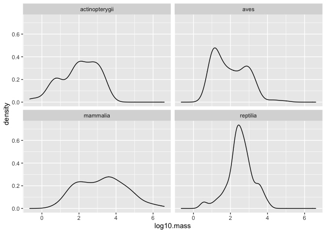

```r
p2+ facet_wrap(~class)
```

Don’t give R a categorical variable that has hundreds of different values! Ex. species. TONS of things to generate!

## Faceting: `facet_grid()`

As you can imagine, there are lots of options for faceting. Another useful facet type is `facet_grid`.

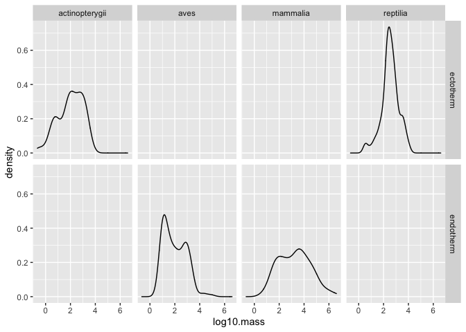

```r
p2+facet_grid(thermoregulation~class)
```

```r
#So two caterogical variables!
#Use facet_grid for 2 categorical variables
```

```r
pdf("homerange.pdf") #pdf(file, then file type)
p2 #Name of plot you want to export (stored as an object)
dev.off() #Then close the device (dev.off = close it)
```

```r
#Need to tell R what you want to export
```

## That’s it, let’s take a break!

–>[Home](https://jmledford3115.github.io/datascibiol/)